# Вероятность летального исхода после падения с электросамоката.

Евгений Бердинских

2024-11-02

## Описание данных

Данные пациентов, госпитализированных в больницу после получения черепно-мозговой травмы вследствие падения с электросамоката, представлены в файле **trauma.xlsx**. Ниже приведены первые 10 строчек из датасета, а также описательная статистика для представленных в нем переменных.

```r
data <- read_excel("data/raw/trauma.xlsx")

head(data, 10) %>%
  flextable() %>%
  autofit() %>%
  theme_box()
```

| id | Name | Sex | Age | Height | Weight | SBP | DBP | FOUR | GSC | Hb | Death |
| --- | --- | --- | --- | --- | --- | --- | --- | --- | --- | --- | --- |
| 1 | Jecelle Oberly | Female | 24 | 68" | 176.0 | 102 | 78 | 10 | 8 | 11.4 | 1 |
| 2 | Halie Mccone | Female | 35 | 69.8" | 183.9 | 116 | 86 | 9 | 7 | 12.2 | 0 |
| 3 | Kole Cook | Male | 39 | 72.8" | 210.1 | 122 | 102 | 12 | 12 | 15.0 | 0 |
| 4 | Patricia Davis | Female | 20 | 70.5" | 195.4 | 120 | 100 | 11 | 9 | 12.2 | 0 |
| 5 | Grace Cress | Female | 63 | 66.8" | 169.0 | 112 | 84 | 9 | 7 | 12.4 | 1 |
| 6 | Joseph Benbrook | Male | 60 | 72.4" | 201.6 | 118 | 88 | 13 | 11 | 15.0 | 0 |
| 7 | Kelsie Coombs | Female | 63 | 69.6" | 216.0 | 122 | 100 | 10 | 9 | 11.8 | 0 |
| 8 | Aaron Eddy | Male | 26 | 74.7" | 194.1 | 114 | 94 | 11 | 10 | 14.4 | 0 |
| 9 | Victoria Hartman-Crowe | Female | 20 | 69.5" | 192.1 | 104 | 84 | 10 | 9 | 11.4 | 0 |
| 10 | Lindsay Locher | Female | 25 | 69.1" | 170.5 | 106 | 78 | 7 | 5 | 12.2 | 1 |

```r
skim(data)
```

Data summary

| Name | data |
| --- | --- |
| Number of rows | 1024 |
| Number of columns | 12 |
| _______________________ |  |
| Column type frequency: |  |
| character | 3 |
| numeric | 9 |
| ________________________ |  |
| Group variables | None |

**Variable type: character**

| skim_variable | n_missing | complete_rate | min | max | empty | n_unique | whitespace |
| --- | --- | --- | --- | --- | --- | --- | --- |
| Name | 0 | 1 | 9 | 25 | 0 | 1023 | 0 |
| Sex | 0 | 1 | 4 | 6 | 0 | 2 | 0 |
| Height | 0 | 1 | 3 | 5 | 0 | 143 | 0 |

**Variable type: numeric**

| skim_variable | n_missing | complete_rate | mean | sd | p0 | p25 | p50 | p75 | p100 | hist |
| --- | --- | --- | --- | --- | --- | --- | --- | --- | --- | --- |
| id | 0 | 1 | 512.50 | 295.75 | 1.0 | 256.75 | 512.5 | 768.25 | 1024.0 | ▇▇▇▇▇ |
| Age | 0 | 1 | 40.94 | 13.66 | 18.0 | 29.00 | 41.0 | 53.00 | 64.0 | ▇▆▆▇▇ |
| Weight | 0 | 1 | 193.52 | 18.24 | 133.3 | 181.67 | 193.9 | 205.43 | 253.1 | ▁▃▇▃▁ |
| SBP | 0 | 1 | 110.78 | 7.45 | 90.0 | 106.00 | 110.0 | 116.00 | 134.0 | ▁▅▇▃▁ |
| DBP | 0 | 1 | 84.78 | 8.42 | 58.0 | 78.00 | 84.0 | 90.00 | 110.0 | ▁▅▇▅▁ |
| FOUR | 0 | 1 | 8.85 | 3.01 | 0.0 | 7.00 | 9.0 | 11.00 | 16.0 | ▁▅▇▇▂ |
| GSC | 0 | 1 | 7.79 | 2.69 | 3.0 | 6.00 | 8.0 | 10.00 | 14.0 | ▆▇▇▆▂ |
| Hb | 0 | 1 | 12.80 | 2.05 | 0.0 | 12.00 | 13.1 | 14.00 | 16.2 | ▁▁▁▆▇ |
| Death | 0 | 1 | 0.40 | 0.49 | 0.0 | 0.00 | 0.0 | 1.00 | 1.0 | ▇▁▁▁▅ |

Ряд переменных требуют преобразования для удобства дальнейшней работы, кроме того можно добавить пару новых переменных. Ниже приведены первые 10 строчек из **преобразованного датасета**, а также описательная статистика для каждой переменной, разделённая по значениям переменной **Death** (летальный исход в течение 24 часов).

```r
data_clean <- data %>%
  transmute(
    id = as.character(id),
    # Name - ФИО пациента является конфиденциальной информацией
    Sex = as.factor(Sex), Age,
    Height = signif( as.numeric( str_replace(Height,'"', "") ) * 0.0254, 3), # перевод из дюймов в метры
    Weight = signif( Weight / 2.2, 3), # перевод из фунтов в килограммы
    BMI = signif( Weight/ Height^2, 3), # расчёт ИМТ
    SBP, DBP, FOUR, GSC,
    Hb = na_if(Hb, 0), # замена гемоглобина = 0 на NA
    Hb_level = case_when( # представление уровня гемоглобина в виде категориальной переменной
      is.na(Hb) ~ "Неизвестно",
      Sex == "Male" & Hb > 16 ~ "Выше нормы",
      Sex == "Male" & Hb < 13.5 ~ "Ниже нормы",
      Sex == "Female" & Hb > 14 ~ "Выше нормы",
      Sex == "Female" & Hb < 12 ~ "Ниже нормы",
      TRUE ~ "В пределах нормы" ),
    Death = factor(Death, levels = c(0, 1), labels = c("No", "Yes"))
    )

head(data_clean, 10) %>%
  flextable() %>%
  autofit() %>%
  theme_box()
```

| id | Sex | Age | Height | Weight | BMI | SBP | DBP | FOUR | GSC | Hb | Hb_level | Death |
| --- | --- | --- | --- | --- | --- | --- | --- | --- | --- | --- | --- | --- |
| 1 | Female | 24 | 1.73 | 80.0 | 26.7 | 102 | 78 | 10 | 8 | 11.4 | Ниже нормы | Yes |
| 2 | Female | 35 | 1.77 | 83.6 | 26.7 | 116 | 86 | 9 | 7 | 12.2 | В пределах нормы | No |
| 3 | Male | 39 | 1.85 | 95.5 | 27.9 | 122 | 102 | 12 | 12 | 15.0 | В пределах нормы | No |
| 4 | Female | 20 | 1.79 | 88.8 | 27.7 | 120 | 100 | 11 | 9 | 12.2 | В пределах нормы | No |
| 5 | Female | 63 | 1.70 | 76.8 | 26.6 | 112 | 84 | 9 | 7 | 12.4 | В пределах нормы | Yes |
| 6 | Male | 60 | 1.84 | 91.6 | 27.1 | 118 | 88 | 13 | 11 | 15.0 | В пределах нормы | No |
| 7 | Female | 63 | 1.77 | 98.2 | 31.3 | 122 | 100 | 10 | 9 | 11.8 | Ниже нормы | No |
| 8 | Male | 26 | 1.90 | 88.2 | 24.4 | 114 | 94 | 11 | 10 | 14.4 | В пределах нормы | No |
| 9 | Female | 20 | 1.77 | 87.3 | 27.9 | 104 | 84 | 10 | 9 | 11.4 | Ниже нормы | No |
| 10 | Female | 25 | 1.76 | 77.5 | 25.0 | 106 | 78 | 7 | 5 | 12.2 | В пределах нормы | Yes |

```r
data_clean %>%
  select(!id) %>%
  tbl_summary(
    by = Death,
    statistic = list(
      all_continuous() ~ "{mean} ({sd})",
      all_categorical() ~ "{n} / {N} ({p}%)"
    ),
    missing_text = "Пропущенные значения"
  ) %>%
  # tbl_summary(by = Death) %>%
  add_p() %>%
  modify_header(label ~ "**Летальный исход**")
```

| **Летальный исход** | **No**, N = 615<sup>1</sup> | **Yes**, N = 409<sup>1</sup> | **p-value**<sup>2</sup> |
| --- | --- | --- | --- |
| Sex |  |  | 0.5 |
| Female | 226 / 615 (37%) | 158 / 409 (39%) |  |
| Male | 389 / 615 (63%) | 251 / 409 (61%) |  |
| Age | 40 (14) | 42 (14) | 0.14 |
| Height | 1.84 (0.08) | 1.84 (0.08) | 0.3 |
| Weight | 88 (9) | 88 (8) | 0.3 |
| BMI | 26.06 (2.59) | 26.07 (2.58) | >0.9 |
| SBP | 114 (7) | 106 (6) | <0.001 |
| DBP | 88 (8) | 80 (7) | <0.001 |
| FOUR | 10.6 (2.2) | 6.2 (2.0) | <0.001 |
| GSC | 9.29 (2.07) | 5.52 (1.77) | <0.001 |
| Hb | 13.38 (1.19) | 12.44 (1.20) | <0.001 |
| Пропущенные значения | 10 | 6 |  |
| Hb_level |  |  | <0.001 |
| В пределах нормы | 438 / 615 (71%) | 111 / 409 (27%) |  |
| Выше нормы | 1 / 615 (0.2%) | 0 / 409 (0%) |  |
| Неизвестно | 10 / 615 (1.6%) | 6 / 409 (1.5%) |  |
| Ниже нормы | 166 / 615 (27%) | 292 / 409 (71%) |  |

<sup>1</sup> n / N (%); Mean (SD)  
<sup>2</sup> Pearson’s Chi-squared test; Wilcoxon rank sum test; Fisher’s exact test

```r
cat(paste0(

"Стоит обратить внимание на то, что из ", nrow(data_clean), " пациентов у ",
nrow(data_clean %>% filter(Hb_level == "Ниже нормы")),
" был зафиксирован сниженный уровень гемоглобина, что составляет - ",
signif(nrow(data_clean %>% filter(Hb_level == "Ниже нормы"))/nrow(data_clean)*100, 3),
"% от общего числа пациентов.", "\n",
"Кроме того, средний уровень ИМТ у пациентов, включенных в исследование, составил ",
signif(mean(data_clean$BMI), 3), " при стандартном отклонении - ",
signif(sd(data_clean$BMI), 3), ", а от ожирения стадало ",
signif(nrow(data_clean %>% filter(BMI > 30))/nrow(data_clean)*100, 3),
"% пациентов."

))
```

Стоит обратить внимание на то, что из 1024 пациентов у 458 был зафиксирован сниженный уровень гемоглобина, что составляет - 44.7% от общего числа пациентов. Кроме того, средний уровень ИМТ у пациентов, включенных в исследование, составил 26.1 при стандартном отклонении - 2.58, а от ожирения стадало 6.93% пациентов.

## ROC-анализ

### Уровень гемоглобина

Ниже представлена ROC-кривая для предсказания летального исхода в течение 24 часов по переменной, характеризующей уровень гемоглобина:

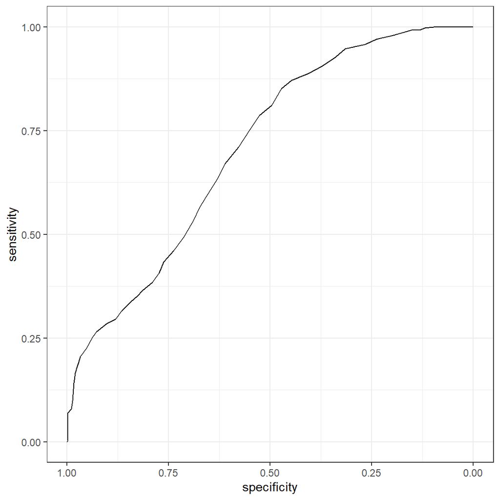

```r
roc_Death_Hb <- roc(Death ~ Hb, data = data_clean, ci = T)
roc_Death_Hb %>% ggroc()+ theme_bw()
```

```r
cat(paste0(

"Форма ROC-кривой указывает на предсказательную способность уровня гемоглобина для летального исхода в течение 24 часов. Площадь под кривой (AUC) составляет ", signif(roc_Death_Hb$ci[2], 3), " (95% ДИ: ", signif(roc_Death_Hb$ci[1], 3), " - ", signif(roc_Death_Hb$ci[3], 3), "), что значительно выше значения 0.5, характерного для случайной классификации. Такое значение AUC может быть объяснено тем, что уровни гемоглобина значимо различаются у пациентов с летальным исходом и без него, что было подтверждено результатами описательной статистики"

))
```

Форма ROC-кривой указывает на предсказательную способность уровня гемоглобина для летального исхода в течение 24 часов. Площадь под кривой (AUC) составляет 0.708 (95% ДИ: 0.676 - 0.739), что значительно выше значения 0.5, характерного для случайной классификации. Такое значение AUC может быть объяснено тем, что уровни гемоглобина значимо различаются у пациентов с летальным исходом и без него, что было подтверждено результатами описательной статистики

### Шкала комы Глазго

Ниже представлена ROC-кривая для предсказания летального исхода в течение 24 часов по переменной, характеризующей балл по шкале комы Глазго при поступлении:

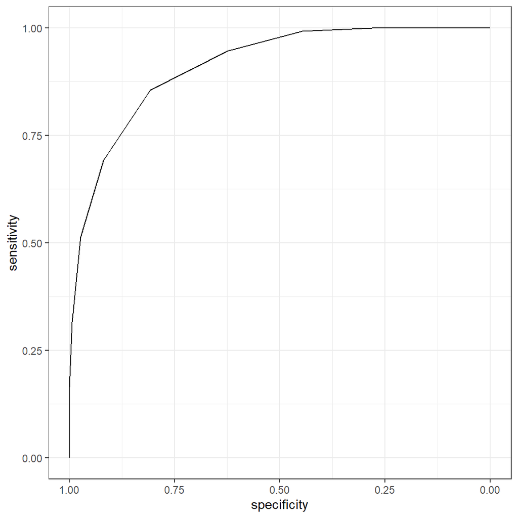

```r
roc_Death_GSC <- roc(Death ~ GSC,
                    data = data_clean,
                    ci = T)

roc_Death_GSC %>%
  ggroc()+
  theme_bw()
```

```r
cat(paste0(

"Площадь под кривой (AUC) составляет ", signif(roc_Death_GSC$ci[2], 3), " (95% ДИ: ", signif(roc_Death_GSC$ci[1], 3), " - ", signif(roc_Death_GSC$ci[3], 3), "), что указывает на высокую предсказательную способность шкалы комы Глазго для летального исхода в течение 24 часов. Оптимальным порогом является значение ",
roc_Death_GSC %>% coords(x = "best", best.method = "closest.topleft") %>% pull(threshold),
" баллов, при котором чувствительность составляет ",
signif(roc_Death_GSC %>% coords(x = "best", best.method = "closest.topleft") %>% pull(specificity) * 100,3),
"%, а специфичность — ",
signif(roc_Death_GSC %>% coords(x = "best", best.method = "closest.topleft") %>% pull(sensitivity) * 100,3), "%."
))
```

[output not shown]

## Количественные переменные

Результаты ROC-анализа для всех количественных переменных в датасете представлены ниже:

```r
roc_Death_num <-
data_clean %>%
  select(where(is.numeric) | Death ) %>%
  pivot_longer(!Death, names_to = "Переменная") %>%
  group_by(Переменная) %>%
  summarise(AUC = roc(Death ~ value, ci = T)$ci[2] %>% signif(3),
            "95% ДИ" = paste0(roc(Death ~ value, ci = T)$ci[1] %>% signif(3),
                              " - ", roc(Death ~ value, ci = T)$ci[3] %>% signif(3) )) %>%
  arrange(desc(AUC))


roc_Death_num %>%
  flextable() %>%
  autofit() %>%
  theme_box()
```

| Переменная | AUC | 95% ДИ |
| --- | --- | --- |
| FOUR | 0.934 | 0.92 - 0.948 |
| GSC | 0.912 | 0.896 - 0.929 |
| SBP | 0.786 | 0.759 - 0.814 |
| DBP | 0.744 | 0.714 - 0.774 |
| Hb | 0.708 | 0.676 - 0.739 |
| Age | 0.527 | 0.491 - 0.563 |
| Weight | 0.518 | 0.482 - 0.554 |
| BMI | 0.499 | 0.463 - 0.535 |
| Height | 0.481 | 0.445 - 0.517 |

Наибольшая площадь под ROC-кривой наблюдается у переменной, характеризующей балл по шкале комы FOUR при поступлении, что указывает на ее высокую предсказательную способность для летального исхода после падения с электросамоката. Это делает шкалу FOUR наиболее информативной переменной для оценки риска летального исхода.

Для переменных Рост, Индекс массы тела, Вес и Возраст 95%-доверительный интервал для AUC включает значение 0.5, что соответствует случайной классификации. Следовательно, эти переменные не обладают значимой предсказательной способностью и не являются информативными для оценки риска летального исхода.